# Practical Machine Learning Project - Body movement data quantification

Simone Di Cicco

8/1/2017

## Introduction

Using devices such as Jawbone Up, Nike FuelBand, and Fitbit it is now possible to collect a large amount of data about personal activity relatively inexpensively. These type of devices are part of the quantified self movement ??? a group of enthusiasts who take measurements about themselves regularly to improve their health, to find patterns in their behavior, or because they are tech geeks. One thing that people regularly do is quantify how much of a particular activity they do, but they rarely quantify how well they do it. In this project, your goal will be to use data from accelerometers on the belt, forearm, arm, and dumbell of 6 participants. They were asked to perform barbell lifts correctly and incorrectly in 5 different ways. More information is available from the website here: http://groupware.les.inf.puc-rio.br/har (see the section on the Weight Lifting Exercise Dataset).

## Data

The training data for this project are available here: - https://d396qusza40orc.cloudfront.net/predmachlearn/pml-training.csv

The test data are available here: - https://d396qusza40orc.cloudfront.net/predmachlearn/pml-testing.csv

## Objective

The goal of your project is to predict the manner in which they did the exercise. This is the “classe” variable in the training set. You may use any of the other variables to predict with. You should create a report describing how you built your model, how you used cross validation, what you think the expected out of sample error is, and why you made the choices you did. You will also use your prediction model to predict 20 different test cases.

## Data Analisys

### Download the dataset

```r
library(caret)
```

```r
library(rpart)
library(rpart.plot)
library(randomForest)
library(corrplot)
library(rattle)
training_url <- "http://d396qusza40orc.cloudfront.net/predmachlearn/pml-training.csv"
testing_url <- "http://d396qusza40orc.cloudfront.net/predmachlearn/pml-testing.csv"
training <- read.csv(url(training_url), na.strings = c("NA", "#DIV/0!", ""))
testing <- read.csv(url(testing_url), na.strings = c("NA", "#DIV/0!", ""))
```

### Cleaning the dataset

```r
# Cleaning variables with NA value.
training_cleaned <- training[, colSums(is.na(training)) == 0]
testing_cleaned <- testing[, colSums(is.na(testing)) == 0]

# Cleaning from varaibles that are useless for an intuitive prediction.
training_cleaned <- training_cleaned[ ,-(1:7)]
testing_cleaned <- testing_cleaned[ ,-(1:7)]
```

### Partitioning the dataset

```r
set.seed(12345)
in_train <- createDataPartition(y = training_cleaned$classe, p = 0.7, list = F)
training_final <- training_cleaned[in_train, ]
testing_final <- testing_cleaned[-in_train, ]
```

To make our job easier we can go to fit a predictive model for the body activity recognition by taking advantage of Random Forests with 5-fold cross validation. This algorithm will select importan variables by itself.

```r
control_random_forest <- trainControl(method = "cv", 5)
model_random_forest <- train(classe ~ ., data = training_final, method = "rf", trControl = control_random_forest, ntree = 100)
model_random_forest
```

```
## Random Forest
##
## 13737 samples
##    52 predictor
##     5 classes: 'A', 'B', 'C', 'D', 'E'
##
## No pre-processing
## Resampling: Cross-Validated (5 fold)
## Summary of sample sizes: 10989, 10990, 10990, 10989, 10990
## Resampling results across tuning parameters:
##
##   mtry  Accuracy   Kappa
##    2    0.9908277  0.9883962
##   27    0.9898815  0.9871999
##   52    0.9851494  0.9812131
##
## Accuracy was used to select the optimal model using  the largest value.
## The final value used for the model was mtry = 2.
```

We now get some performance data

```r
predict_random_forest <- predict(model_random_forest, training_final)
confusionMatrix(training_final$classe, predict_random_forest)
```

```
## Confusion Matrix and Statistics
##
##           Reference
## Prediction    A    B    C    D    E
##          A 3906    0    0    0    0
##          B    0 2658    0    0    0
##          C    0    0 2396    0    0
##          D    0    0    0 2252    0
##          E    0    0    0    0 2525
##
## Overall Statistics
##
##                Accuracy : 1
##                  95% CI : (0.9997, 1)
##     No Information Rate : 0.2843
##     P-Value [Acc > NIR] : < 2.2e-16
##
##                   Kappa : 1
##  Mcnemar's Test P-Value : NA
##
## Statistics by Class:
##
##                      Class: A Class: B Class: C Class: D Class: E
## Sensitivity            1.0000   1.0000   1.0000   1.0000   1.0000
## Specificity            1.0000   1.0000   1.0000   1.0000   1.0000
## Pos Pred Value         1.0000   1.0000   1.0000   1.0000   1.0000
## Neg Pred Value         1.0000   1.0000   1.0000   1.0000   1.0000
## Prevalence             0.2843   0.1935   0.1744   0.1639   0.1838
## Detection Rate         0.2843   0.1935   0.1744   0.1639   0.1838
## Detection Prevalence   0.2843   0.1935   0.1744   0.1639   0.1838
## Balanced Accuracy      1.0000   1.0000   1.0000   1.0000   1.0000
```

```r
accuracy_estimation <- postResample(predict_random_forest, training_final$classe)
accuracy_estimation
```

```
## Accuracy    Kappa
##        1        1
```

```r
out_of_sample_error_estimation <- 1 - as.numeric(confusionMatrix(training_final$classe, predict_random_forest)$overall[1])
out_of_sample_error_estimation
```

```
## [1] 0
```

### Predicting the Test dataset

We can apply the made model to the original test dataset.

```r
prediction_test_result <- predict(model_random_forest, testing_cleaned)
prediction_test_result
```

```
##  [1] B A B A A E D B A A B C B A E E A B B B
## Levels: A B C D E
```

### Figures

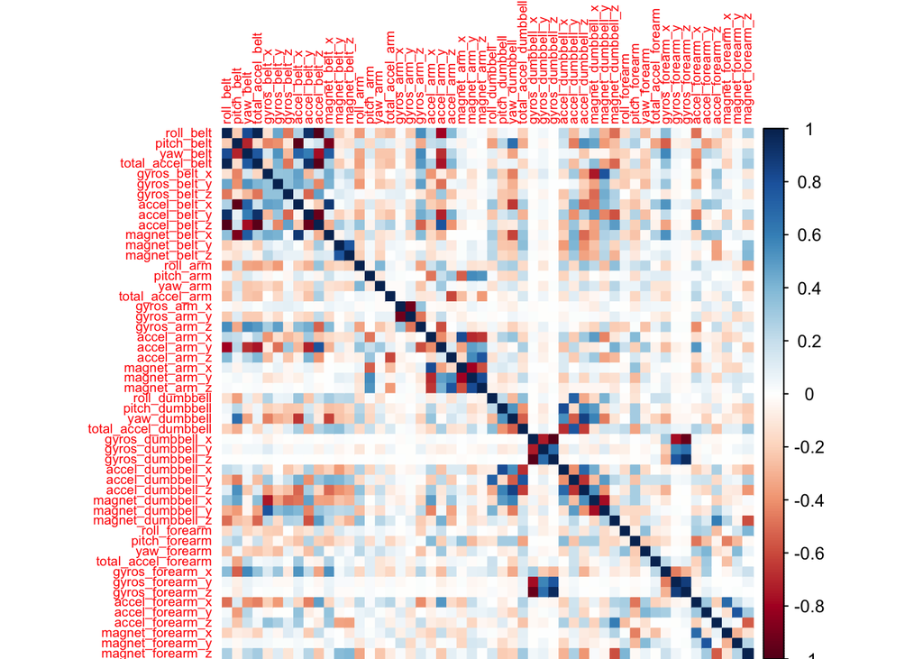

```r
correlation_matrix <- cor(training_final[ ,-length(names(training_final))])
corrplot(correlation_matrix, method = "color", tl.cex = 0.60)
```

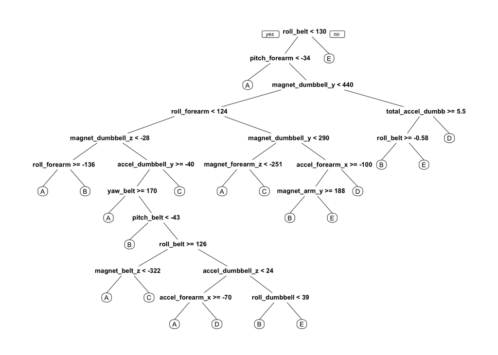

```r
tree_model <- rpart(classe ~ ., data = training_final, method = "class")
prp(tree_model)
```

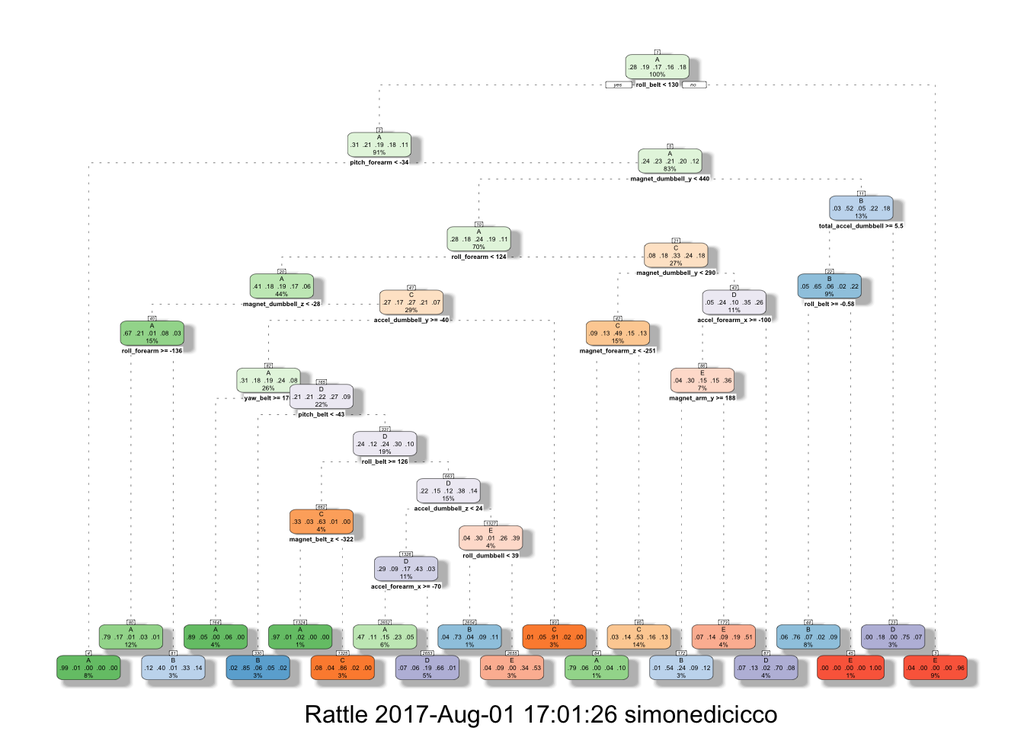

```r
fancyRpartPlot(tree_model, tweak = 1.3)
```